# A Quick Introduction to iNEXT.4steps via Examples

Anne Chao and Kai-Hsiang Hu

2024-03-16

`iNEXT.4steps` (iNterpolation and EXTrapolation for four steps of biodiversity) is an original R package which provide an easy complete biological analysis computation. `iNEXT.4steps` expands iNEXT (Chao et al. 2014) to include the estimation of sample completeness and evenness under a unified framework of Hill numbers. `iNEXT.4steps` links sample completeness, diversity estimation, interpolation and extrapolation (iNEXT), and evenness in a fully integrated approach. The pertinent background for the four-step methodology is provided in Chao et al. (2020). The four-step procedures are described in the following:

- **Step 1: Assessment of sample completeness profile**

The sample completeness of order $q \geq 0$ quantifies the proportion of the assemblage’s individuals belonging to detected species, with each individual being proportionally weighted by the (q-1)th power of its abundance. When q=0, sample completeness reduces to the conventional measure of completeness, i.e., the ratio of the observed species richness to the true richness (observed plus undetected). When q=1, the measure reduces to the sample coverage (the proportion of the total number of individuals in the entire assemblage that belong to detected species), a concept original developed by Alan Turing in his cryptographic analysis during WWII. Sample completeness profile depicts its estimate with respect to order $q \geq 0$; this profile fully characterizes the sample completeness of a biological survey.

`iNEXT.4steps` features the estimated profile based on the theory in Chao et al. (2020). If the estimated sample completeness profile is a horizontal line at the level of unity for all orders of $q \geq 0$, then the survey is complete, implying there is no undetected diversity. In most applications, the estimated profile increases with order q, revealing the existence of undetected diversity. The sample completeness estimate for q = 0 provides an upper bound for the proportion of observed species; its complement represents a lower bound for the proportion of undetected species. If data are not sparse, then the sample completeness value for q = 1 accurately measures the proportion of an assemblage’s individuals belonging to detected species; and the values for $q \geq 2$ typically are very close to unity, signifying that almost all highly abundant species (for abundance data) or highly frequent species (for incidence data) had been detected in the reference sample.

- **STEP 2. Examination of the size-based rarefaction and extrapolation sampling curves, and the asymptotic diversity profile for $0 \leq q \leq 2$.**

**(STEP 2a)**. For each dataset, first examine the pattern of the size-based rarefaction and extrapolation sampling curve up to double the reference sample size for q = 0, 1 and 2. If the curve stays at a fixed level (this often occurs for the measures of q = 1 and 2), then our asymptotic estimate presented in Step 2b can be used to accurately infer the true diversity of the entire assemblage. Otherwise, our asymptotic diversity estimate represents only a lower bound.

**(STEP 2b)**. When the true diversity can be accurately inferred, the extent of undetected diversity within each dataset is obtained by comparing the estimated asymptotic diversity profile and empirical profile; the difference in diversity between any two assemblages can be evaluated and tested for significance.

- **STEP 3. Examination of non-asymptotic coverage-based rarefaction and extrapolation analysis for orders q = 0, 1 and 2.**

When sampling data do not contain sufficient information to accurately infer true diversity, fair comparisons of diversity across multiple assemblages should be made by standardizing the sample coverage (i.e., comparing diversity for a standardized fraction of an assemblage’s individuals). This comparison can be done based on seamless integration of coverage-based rarefaction and extrapolation sampling curves up to a maximum coverage (C_max = the minimum sample coverage among all samples extrapolated to double reference sizes).

NOTE: In STEP 2 and STEP 3, iNEXT.4steps only deals with taxonomic/species diversity. Researchers who are interested in phylogenetic diversity and functional diversity should use iNEXT.3D package from [CRAN] and see the relevant paper (Chao et al. 2021) for methodology.

- **STEP 4. Assessment of evenness profiles**

Chao and Ricotta (2019) developed five classes of evenness measures parameterized by order $q \geq 0$. All classes of evenness measures are functions of diversity and species richness, and all are standardized to the range of [0, 1] to adjust for the effect of differing species richness. Evenness profile depicts evenness estimate with respect to order $q \geq 0$. Because true species richness typically cannot be accurately estimated, evenness profile typically can only be accurately measured when both diversity and richness are computed at a fixed level of sample coverage up to a maximum coverage C_max defined in Step 3. iNEXT.4steps features one class of evenness measure (as well as Pielou’s J’), but the other four classes are also provided.

`iNEXT.4steps` provides four functions for users to compute and visualize sample completeness curves and evenness curves: `Completeness` and `Evenness` for computation, and `ggCompleteness` and `ggEvenness` for visualization. The most comprehensive function `iNEXT4steps` gathers `iNEXT3D`, `ObsAsy3D`, `Completeness` and `Evenness` into a summary table and a figure. In this document, we will give a quick introduction demonstrating how to run these functions. Detailed information about these function settings is provided in the `iNEXT.4steps` manual, which can be found in [CRAN]. See Chao et al. (2020) to get more details.

## How to cite

If you publish your work based on results from iNEXT.4steps package, you should make references to the following methodology paper and the package:

- Chao, A., Y. Kubota, D. Zeleny, C.-H. Chiu, C.-F. Li, B. Kusumoto, M. Yasuhara, S. Thorn, C.-L. Wei, M. J. Costello, and R. K. Colwell (2020). Quantifying sample completeness and comparing diversities among assemblages. Ecological Research, 35, 292-314.

## SOFTWARE NEEDED TO RUN INEXT IN R

- Required: [R](https://cran.r-project.org/)
- Suggested: [RStudio IDE](https://posit.co/products/open-source/rstudio/#Desktop)

## HOW TO RUN INEXT.4STEPS:

The `iNEXT.4steps` package can be downloaded from [CRAN] or Anne Chao’s [iNEXT.4steps_github](https://github.com/AnneChao/iNEXT.4steps). For a first-time installation, some additional packages must be installed and loaded; see package manual.

```r
## install iNEXT.4steps package from CRAN
install.packages("iNEXT.4steps")

## install the latest version from github
install.packages('devtools')
library(devtools)
install_github('AnneChao/iNEXT.4steps')

## import packages
library(iNEXT.4steps)
```

An online version of iNEXT.4steps (https://chao.shinyapps.io/iNEXT_4steps/) is also available for users without R background.

## DATA INPUT FORMAT

### Species abundance/incidence data format

For `iNEXT.3D` package, information on species identity (or any unique identification code) and assemblage affiliation is required for PD and FD. Two types of species abundance/incidence data are supported:

1. Individual-based abundance data (`datatype = "abundance"`): When there are multiple assemblages, in addition to the assemblage/site names (as column names) and the species names (as row names), species abundance data (reference sample) can be input as a species (in rows) by assemblage (in columns) matrix/data.frame or a list of species abundance vectors. In the special case that there is only one assemblage, all data should be read in one column.
2. Sampling-unit-based incidence data: Incidence-raw data (`datatype = "incidence_raw"`): for each assemblage, input data for a reference sample consist of a species-by-sampling-unit matrix, in addition to the sampling-unit names (as column names) and the species names (as row names). When there are N assemblages, input data consist of N lists of matrices, and each matrix is a species-by-sampling-unit matrix. Each element in the incidence raw matrix is 1 for a detection, and 0 for a non-detection. Input a matrix which combines data for all assemblages is allowed, but the argument `nT` in the function `iNEXT3D` must be specified so that the number of sampling units in each assemblage is specified.

For example, the dataset `Data_spider` included in the `iNEXT.4steps` package consists of species sample abundances of two assemblages/sites: “Open” and “Closed”. Run the following code to view the first 15 rows of the abundance data.

```r
data("Data_spider")
Data_spider
```

```
                         Open Closed
Pardosa_lugubris          350     10
Alopecosa_taeniata        325     55
Coelotes_terrestris       237    502
Pardosa_riparia           102      1
Haplodrassus_signifer      91      3
Gnaphosa_badia             72      4
Callobius_claustrarius     68    171
Harpactea_lepida           61    140
Tenuiphantes_tenebricola   53    180
Cybaeus_angustiarum        50     24
Inermocoelotes_inermis     50     76
Pardosa_ferruginea         37     10
Histopona_torpida          30     28
Xerolycosa_nemoralis       29      0
Amaurobius_fenestralis     17     35
```

We use incidence raw data (`Data_woody_plant`) collected from four sites, namely `"Upper_cloud"`, `"Lower_cloud"`, `"Lowland"`, and `"Monsoon"`, as an example. Run the following code to view the first 6 rows and first 6 columns for each site.

```r
data("Data_woody_plant")
Data_woody_plant
```

```
$Upper_cloud
                                                      Upper_cloud_unit_1 Upper_cloud_unit_2 Upper_cloud_unit_3 Upper_cloud_unit_4 Upper_cloud_unit_5 Upper_cloud_unit_6
Abelia_chinensis_R._Br._var._ionandra_(Hayata)_Masam.                  0                  0                  0                  0                  0                  0
Abies_kawakamii_(Hayata)_Ito                                           0                  0                  0                  0                  0                  0
Acer_albopurpurascens_Hayata                                           0                  0                  0                  0                  0                  0
Acer_kawakamii_Koidzumi                                                0                  0                  0                  0                  0                  0
Acer_morrisonense_Hayata                                               0                  1                  0                  0                  1                  0
Acer_palmatum_Thunb._var._pubescens_Li                                 0                  0                  0                  0                  0                  0

$Lower_cloud
                                       Lower_cloud_unit_1 Lower_cloud_unit_2 Lower_cloud_unit_3 Lower_cloud_unit_4 Lower_cloud_unit_5 Lower_cloud_unit_6
Abies_kawakamii_(Hayata)_Ito                            0                  0                  0                  0                  0                  0
Acer_albopurpurascens_Hayata                            0                  0                  0                  0                  0                  0
Acer_kawakamii_Koidzumi                                 0                  0                  1                  0                  0                  0
Acer_morrisonense_Hayata                                1                  1                  0                  0                  0                  0
Acer_palmatum_Thunb._var._pubescens_Li                  0                  0                  0                  0                  0                  0
Acer_serrulatum_Hayata                                  0                  0                  0                  0                  0                  0

$Lowland
                                 Lowland_unit_1 Lowland_unit_2 Lowland_unit_3 Lowland_unit_4 Lowland_unit_5 Lowland_unit_6
Acacia_confusa_Merr.                          0              0              0              0              0              0
Acer_albopurpurascens_Hayata                  0              0              0              0              0              0
Acer_kawakamii_Koidzumi                       0              0              0              0              0              0
Acer_serrulatum_Hayata                        0              0              0              0              0              0
Adinandra_formosana_Hayata                    0              0              0              0              0              0
Albizia_falcata_Bacher_ex_Merill              0              0              0              1              0              0

$Monsoon
                                           Monsoon_unit_1 Monsoon_unit_2 Monsoon_unit_3 Monsoon_unit_4 Monsoon_unit_5 Monsoon_unit_6
Acacia_confusa_Merr.                                    0              0              0              1              0              0
Acer_kawakamii_Koidzumi                                 0              0              0              0              0              0
Acer_morrisonense_Hayata                                0              0              0              0              0              0
Acer_serrulatum_Hayata                                  0              0              0              0              0              1
Actinidia_chinensis_Planch._var._setosa_Li              0              0              0              0              0              0
Adinandra_formosana_Hayata                              0              1              0              1              1              1
```

## MAIN FUNCTION iNEXT4steps()

We first describe the main function `iNEXT4steps()` with default arguments:

```r
iNEXT4steps(data, q = seq(0, 2, 0.2), datatype = "abundance",
            nboot = 30, conf = 0.95, nT = NULL, details = FALSE)
```

The arguments of this function are briefly described below, and will explain details by illustrative examples in later text.

Argument

Description

`data`

1. For `datatype = "abundance"`, data can be input as a vector of species abundances (for a single assemblage), matrix/data.frame (species by assemblages), or a list of species abundance vectors.
2. For `datatype = "incidence_raw"`, data can be input as a list of matrix/data.frame (species by sampling units); data can also be input as a matrix/data.frame by merging all sampling units across assemblages based on species identity; in this case, the number of sampling units (nT, see below) must be input.

`q`

a numerical vector specifying the diversity orders for q-profile output. Default is `seq(0, 2, by = 0.2)`.

`datatype`

data type of input data: individual-based abundance data (`datatype = "abundance"`) or species by sampling-units incidence matrix (`datatype = "incidence_raw"`) with all entries being 0 (non-detection) or 1 (detection)

`nboot`

a positive integer specifying the number of bootstrap replications when assessing sampling uncertainty and constructing confidence intervals. Enter 0 to skip the bootstrap procedures. Default is 30.

`conf`

a positive number < 1 specifying the level of confidence interval. Default is 0.95.

`nT`

(required only when `datatype = “incidence_raw”` and input data in a single matrix/data.frame) a vector of positive integers specifying the number of sampling units in each assemblage. If assemblage names are not specified (i.e.,

```
names(nT) =
NULL
```

), then assemblages are automatically named as “assemblage1”, “assemblage2”,…, etc.

`details`

a logical variable to decide whether do you want to print out the detailed value for each plots, default is `FALSE`.

The output of `iNEXT4steps` will have three parts (if `details = TRUE`): `$summary`, `$figure`, and `$details`. It may take some time to compute when data size is large or `nboot` is large.

## 4 STEPS VIA EXAMPLES

`"abundance Data"` is used for a random sampling scheme. If the species has aggregation effect, such as trees or plants, then please set `datatype = "incidence_raw"`. First, we use data `Data_spider` to compute taxonomic diversity.

### EXAMPLE 1: 4 steps for abundance data

Datasets `Data_spider` were sampled in a mountain forest ecosystem in the Bavarian Forest National Park, Germany (Thorn et al. 2016, 2017). A total of 12 experimental plots were established in “closed forest” stands (6 plots) and “open forest” stands with naturally occurring gaps and edges (6 plots) to assess the effects of microclimate on communities of epigeal (ground-dwelling) spiders. Epigeal spiders were sampled over three years with four pitfall traps in each plot, yielding a total of 3171 individuals belonging to 85 species recorded in the pooled habitat. More details refer to data Source : A mountain forest ecosystem in the Bavarian Forest National Park, Germany (Thorn et al. 2016, 2017).

Run the following code to get the output from iNEXT4steps.

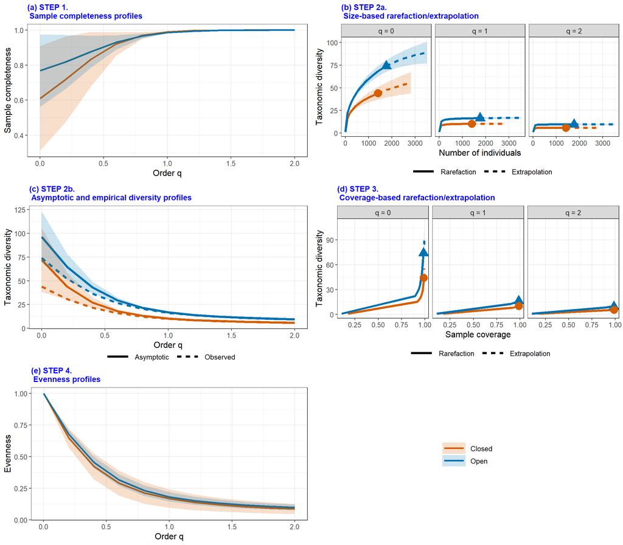

```r
data(Data_spider)
output1 <- iNEXT4steps(data = Data_spider, datatype = "abundance")
output1$summary
$`STEP 1. Sample completeness profiles`
  Assemblage q = 0 q = 1 q = 2
1     Closed  0.61  0.99     1
2       Open  0.77  0.99     1

$`STEP 2. Asymptotic analysis`
  Assemblage               qTD TD_obs TD_asy  s.e. qTD.LCL qTD.UCL
1     Closed  Species richness  44.00  72.11 22.05   28.88  115.33
2     Closed Shannon diversity  10.04  10.30  0.44    9.44   11.16
3     Closed Simpson diversity   5.71   5.73  0.23    5.27    6.19
4       Open  Species richness  74.00  96.31 13.74   69.38  123.24
5       Open Shannon diversity  16.34  16.84  0.60   15.66   18.01
6       Open Simpson diversity   9.41   9.46  0.32    8.83   10.09

$`STEP 3. Non-asymptotic coverage-based rarefaction and extrapolation analysis`
  Cmax = 0.994 q = 0 q = 1 q = 2
1       Closed  55.6  10.2  5.72
2         Open  86.5  16.6  9.43

$`STEP 4. Evenness among species abundances`
       Pielou J' q = 1 q = 2
Closed      0.58  0.17  0.09
Open        0.63  0.18  0.10
output1$figure[[6]]
```

`$summary` lists all biological summaries according to Chao et al. (2020). There are four parts corresponding to each step in the paper. They analysis and explain biological data from different and superimposed side. User can easily compare difference between each assemblages.

`$figure` visualize the statistics by continuous curves. There are five individual figures and an overall figure in `$figure`. `iNEXT4stpes` provides a standard analysis process from figure (a) to figure (e). User can analyze the process of biodiversity through these figures.

`$details` contains four parts: `Sample Completeness`, `iNEXT`, `Asymptotic Diversity`, `Evenness`. They are the computing values which are used to plot each figure in `$figure`.

### EXAMPLE 2: 4 steps for incidence data

Incidence raw data is a species-by-incidence-sampling-units matrix/data.frame. We split a space into several quadrats and only record whether the species is detected or undetected in each quadrat. According to this sampling scheme, `incidence_raw` data can only contains value “zero” (undetected) or “one” (detected) in matrix/data frame (species by assemblages).

Datasets `Woody plants` are a subset of The National Vegetation Database of Taiwan (AS-TW-001), sampled between 2003 and 2007 within the first national vegetation inventory project (Chiou et al. 2009). Over 3600 vegetation plots, each 20x20-m in area, were set up in various locations in Taiwan, and all woody plant individuals taller than 2 meters were recorded in each plot. For illustration here, we selected only plots belonging to two vegetation types (according to Li et al. 2013): Pyrenaria-Machilus subtropical winter monsoon forest and Chamaecyparis montane mixed cloud forest, sampled in the northern part of Taiwan (in ecoregions 7 and 8 according to Su 1985).

Run the following code to get the output from iNEXT4steps.

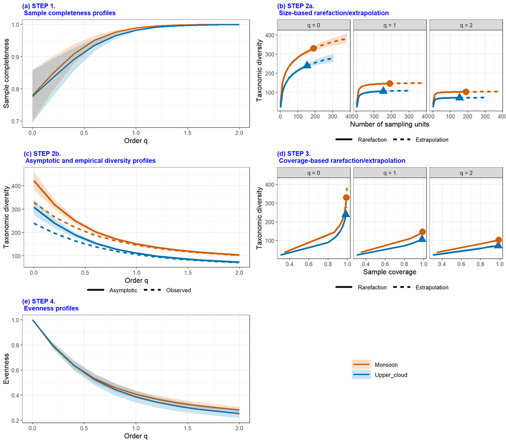

```r
data(Data_woody_plant)
output2 <- iNEXT4steps(data = Data_woody_plant[c(1,4)], datatype = "incidence_raw")
output2$summary
$`STEP 1. Sample completeness profiles`
   Assemblage q = 0 q = 1 q = 2
1     Monsoon  0.78  0.99     1
2 Upper_cloud  0.78  0.98     1

$`STEP 2. Asymptotic analysis`
   Assemblage               qTD TD_obs TD_asy  s.e. qTD.LCL qTD.UCL
1     Monsoon  Species richness  329.0  421.7 26.32   370.1   473.2
2     Monsoon Shannon diversity  145.7  150.2  1.59   147.0   153.3
3     Monsoon Simpson diversity  102.3  103.3  1.25   100.9   105.8
4 Upper_cloud  Species richness  239.0  307.8 20.12   268.4   347.2
5 Upper_cloud Shannon diversity  105.5  110.5  1.94   106.7   114.3
6 Upper_cloud Simpson diversity   71.2   72.2  1.28    69.7    74.7

$`STEP 3. Non-asymptotic coverage-based rarefaction and extrapolation analysis`
  Cmax = 0.993 q = 0 q = 1 q = 2
1      Monsoon   360   147 102.7
2  Upper_cloud   279   109  71.7

$`STEP 4. Evenness among species abundances`
            Pielou J' q = 1 q = 2
Monsoon          0.85  0.41  0.28
Upper_cloud      0.83  0.39  0.25
output2$figure[[6]]
```

## FUNCTION Completeness: SAMPLE COMPLETENESS PROFILES

`iNEXT.4steps` provides function `Completeness()` to compute estimated sample completeness with order q. The arguments is below:

```r
Completeness(data, q = seq(0, 2, 0.2), datatype = "abundance", nboot = 50,
             conf = 0.95, nT = NULL)
```

Argument

Description

`data`

1. For `datatype = "abundance"`, data can be input as a vector of species abundances (for a single assemblage), matrix/data.frame (species by assemblages), or a list of species abundance vectors.
2. For `datatype = "incidence_freq"`, data can be input as a vector of incidence frequencies (for a single assemblage), matrix/data.frame (species by assemblages), or a list of incidence frequencies; the first entry in all types of input must be the number of sampling units in each assemblage.
3. For `datatype = "incidence_raw"`, data can be input as a list of matrix/data.frame (species by sampling units); data can also be input as a matrix/data.frame by merging all sampling units across assemblages based on species identity; in this case, the number of sampling units (nT, see below) must be input.

`q`

a numerical vector specifying the diversity orders. Default is `seq(0, 2, by = 0.2)`.

`datatype`

data type of input data: individual-based abundance data (`datatype = "abundance"`), sampling-unit-based incidence frequencies data (`datatype = "incidence_freq"`), or species by sampling-units incidence matrix (`datatype = "incidence_raw"`) with all entries being 0 (non-detection) or 1 (detection)

`nboot`

a positive integer specifying the number of bootstrap replications when assessing sampling uncertainty and constructing confidence intervals. Enter 0 to skip the bootstrap procedures. Default is 50.

`conf`

a positive number < 1 specifying the level of confidence interval. Default is 0.95.

`nT`

(required only when `datatype = "incidence_raw"` and input data is matrix/data.frame) a vector of nonnegative integers specifying the number of sampling units in each assemblage. If assemblage names are not specified, then assemblages are automatically named as “assemblage1”, “assemblage2”,…, etc.

## FUNCTION ggCompleteness(): GRAPHIC DISPLAYS OF SAMPLE COMPLETENESS PROFILES

`iNEXT.4steps` also provides a visualized function `ggCompleteness` to plot the output from `Completeness()`:

```r
ggCompleteness(output)
```

| Argument | Description |
| --- | --- |
| `output` | the output of the function `Completeness`. |

Following are two simple examples for functions `Completeness` and `ggCompleteness`.

### Sample completeness profiles for abundance data

Use abundance data `Data_spider` to compute estimated sample completeness.

```r
data(Data_spider)
output1 <- Completeness(data = Data_spider, datatype = "abundance")
output1
   Order.q Estimate.SC     s.e. SC.LCL SC.UCL Assemblage
1      0.0       0.768 1.04e-01  0.564  0.972       Open
2      0.2       0.818 7.75e-02  0.666  0.970       Open
3      0.4       0.877 4.63e-02  0.786  0.968       Open
4      0.6       0.930 2.12e-02  0.889  0.972       Open
5      0.8       0.966 7.66e-03  0.951  0.982       Open
6      1.0       0.986 2.37e-03  0.981  0.990       Open
7      1.2       0.994 7.08e-04  0.993  0.996       Open
8      1.4       0.998 2.51e-04  0.997  0.998       Open
9      1.6       0.999 1.09e-04  0.999  0.999       Open
10     1.8       1.000 5.01e-05  1.000  1.000       Open
11     2.0       1.000 2.23e-05  1.000  1.000       Open
12     0.0       0.610 1.55e-01  0.306  0.915     Closed
13     0.2       0.718 1.18e-01  0.487  0.949     Closed
14     0.4       0.834 6.61e-02  0.704  0.963     Closed
15     0.6       0.922 2.56e-02  0.871  0.972     Closed
16     0.8       0.969 7.37e-03  0.955  0.984     Closed
17     1.0       0.989 1.87e-03  0.986  0.993     Closed
18     1.2       0.997 5.70e-04  0.996  0.998     Closed
19     1.4       0.999 2.30e-04  0.999  0.999     Closed
20     1.6       1.000 9.59e-05  1.000  1.000     Closed
21     1.8       1.000 3.79e-05  1.000  1.000     Closed
22     2.0       1.000 1.42e-05  1.000  1.000     Closed
```

The following commands plot sample completeness curves, along with its confidence interval for q between 0 to 2.

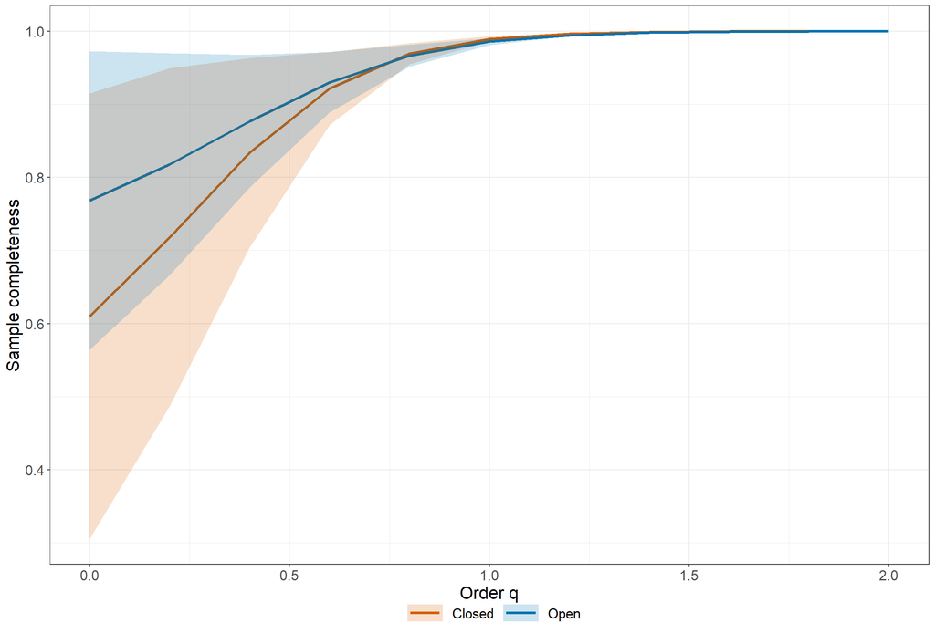

```r
ggCompleteness(output1)
```

### Sample completeness profiles for incidence data

Use incidence frequency data `woody plants` to compute sample completeness.

```r
data(Data_woody_plant)
output2 <- Completeness(data = Data_woody_plant[c(1,4)], datatype = "incidence_raw")
output2
   Order.q Estimate.SC     s.e. SC.LCL SC.UCL  Assemblage
1      0.0       0.777 5.17e-02  0.675  0.878 Upper_cloud
2      0.2       0.836 3.52e-02  0.767  0.905 Upper_cloud
3      0.4       0.892 2.07e-02  0.851  0.932 Upper_cloud
4      0.6       0.935 1.05e-02  0.915  0.956 Upper_cloud
5      0.8       0.965 4.62e-03  0.956  0.974 Upper_cloud
6      1.0       0.982 1.85e-03  0.979  0.986 Upper_cloud
7      1.2       0.992 7.42e-04  0.990  0.993 Upper_cloud
8      1.4       0.996 3.61e-04  0.995  0.997 Upper_cloud
9      1.6       0.998 2.12e-04  0.998  0.999 Upper_cloud
10     1.8       0.999 1.28e-04  0.999  0.999 Upper_cloud
11     2.0       1.000 7.45e-05  1.000  1.000 Upper_cloud
12     0.0       0.780 4.70e-02  0.688  0.872     Monsoon
13     0.2       0.849 3.06e-02  0.789  0.909     Monsoon
14     0.4       0.909 1.67e-02  0.876  0.941     Monsoon
15     0.6       0.951 7.63e-03  0.936  0.966     Monsoon
16     0.8       0.976 3.01e-03  0.970  0.982     Monsoon
17     1.0       0.989 1.05e-03  0.987  0.991     Monsoon
18     1.2       0.995 3.47e-04  0.994  0.996     Monsoon
19     1.4       0.998 1.41e-04  0.998  0.998     Monsoon
20     1.6       0.999 7.84e-05  0.999  0.999     Monsoon
21     1.8       1.000 4.56e-05  1.000  1.000     Monsoon
22     2.0       1.000 2.50e-05  1.000  1.000     Monsoon
```

The following commands plot sample completeness curves, along with its confidence interval for q between 0 to 2.

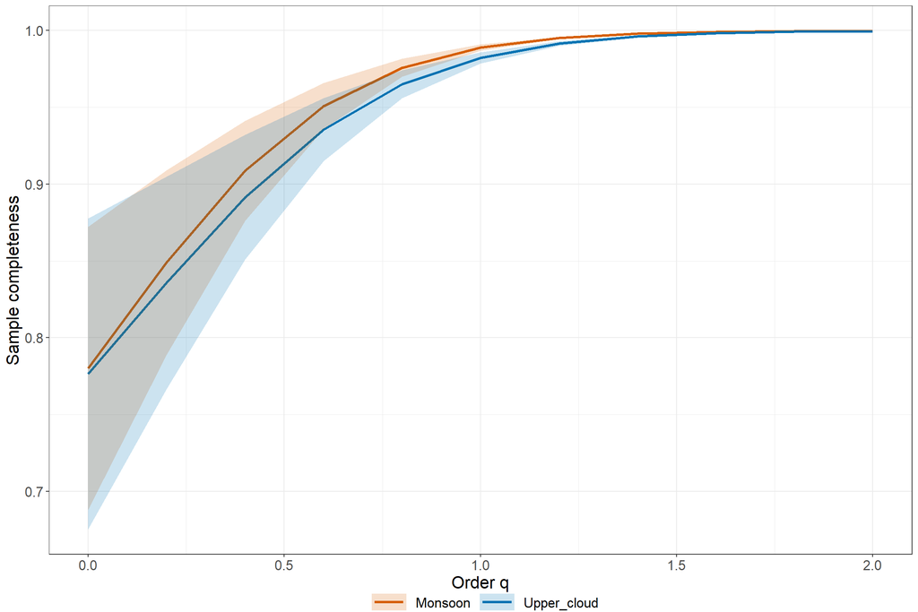

```r
ggCompleteness(output2)
```

## FUNCTION Evenness: EVENNESS PROFILES

`iNEXT.4steps` provides the function `Evenness()` to compute observed eveness or estimated evenness under specified sample coverage. The argument is below:

```r
Evenness(data, q = seq(0, 2, 0.2), datatype = "abundance", method = "Estimated",
         nboot = 50, conf = 0.95, nT = NULL, E.class = 1:5, SC = NULL)
```

Argument

Description

`data`

1. For `datatype = "abundance"`, data can be input as a vector of species abundances (for a single assemblage), matrix/data.frame (species by assemblages), or a list of species abundance vectors.
2. For `datatype = "incidence_freq"`, data can be input as a vector of incidence frequencies (for a single assemblage), matrix/data.frame (species by assemblages), or a list of incidence frequencies; the first entry in all types of input must be the number of sampling units in each assemblage.
3. For `datatype = "incidence_raw"`, data can be input as a list of matrix/data.frame (species by sampling units); data can also be input as a matrix/data.frame by merging all sampling units across assemblages based on species identity; in this case, the number of sampling units (nT, see below) must be input.

`q`

a numerical vector specifying the diversity orders. Default is

```
(0,
0.2, 0.4,…,2)
```

.

`datatype`

data type of input data: individual-based abundance data (`datatype = "abundance"`), sampling-unit-based incidence frequencies data (`datatype = "incidence_freq"`), or species by sampling-units incidence matrix (`datatype = "incidence_raw"`) with all entries being 0 (non-detection) or 1 (detection)

`method`

a binary calculation method with `“Estimated”` or `“Observed”`.

`nboot`

a positive integer specifying the number of bootstrap replications when assessing sampling uncertainty and constructing confidence intervals. Enter 0 to skip the bootstrap procedures. Default is `50`.

`conf`

a positive number < `1` specifying the level of confidence interval. Default is `0.95`.

`nT`

(required only when `datatype = "incidence_raw"` and input data is matrix/data.frame) a vector of nonnegative integers specifying the number of sampling units in each assemblage. If assemblage names are not specified, then assemblages are automatically named as “assemblage1”, “assemblage2”,…, etc.

`E.class`

an integer vector between 1 to 5.

`SC`

(required only when method = “Estimated”) a standardized coverage for calculating estimated evenness. If `NULL`, then this function computes the diversity estimates for the minimum sample coverage among all samples extrapolated to double reference sizes (Cmax).

## FUNCTION ggEvenness(): GRAPHIC DISPLAYS OF EVENNESS PROFILES

`iNEXT.4steps` provide a function `ggEvenness()` to plot the output from `Evenness()`.

```r
ggEvenness(output)
```

| Argument | Description |
| --- | --- |
| `output` | the output of the function `Evenness`. |

Following are four simple examples for functions `Evenness` and `ggEvenness`.

### Observed evenness profiles for abundance data

Use abundance data `Data_spider` to compute observed evenness. Here only show the output for first class of evenness.

```r
data(Data_spider)
output1 <- Evenness(data = Data_spider, datatype = "abundance",
                    method = "Observed", E.class = 1:5)
output1$E1
   Order.q Evenness    s.e. Even.LCL Even.UCL Assemblage   Method
1      0.0    1.000 0.00000    1.000    1.000       Open Observed
2      0.2    0.747 0.00626    0.735    0.759       Open Observed
3      0.4    0.627 0.00841    0.611    0.644       Open Observed
4      0.6    0.590 0.00888    0.573    0.607       Open Observed
5      0.8    0.604 0.00853    0.588    0.621       Open Observed
6      1.0    0.649 0.00775    0.634    0.664       Open Observed
7      1.2    0.708 0.00680    0.695    0.721       Open Observed
8      1.4    0.769 0.00588    0.758    0.781       Open Observed
9      1.6    0.825 0.00507    0.815    0.834       Open Observed
10     1.8    0.870 0.00433    0.862    0.879       Open Observed
11     2.0    0.906 0.00364    0.899    0.913       Open Observed
12     0.0    1.000 0.00000    1.000    1.000     Closed Observed
13     0.2    0.737 0.00972    0.718    0.756     Closed Observed
14     0.4    0.614 0.01378    0.587    0.641     Closed Observed
15     0.6    0.571 0.01485    0.542    0.601     Closed Observed
16     0.8    0.577 0.01425    0.549    0.604     Closed Observed
17     1.0    0.609 0.01283    0.584    0.635     Closed Observed
18     1.2    0.657 0.01122    0.635    0.679     Closed Observed
19     1.4    0.709 0.00984    0.690    0.728     Closed Observed
20     1.6    0.760 0.00885    0.742    0.777     Closed Observed
21     1.8    0.805 0.00814    0.789    0.821     Closed Observed
22     2.0    0.844 0.00755    0.829    0.859     Closed Observed
```

The following commands plot the evenness curves for five classes, along with its confidence interval for q between 0 to 2.

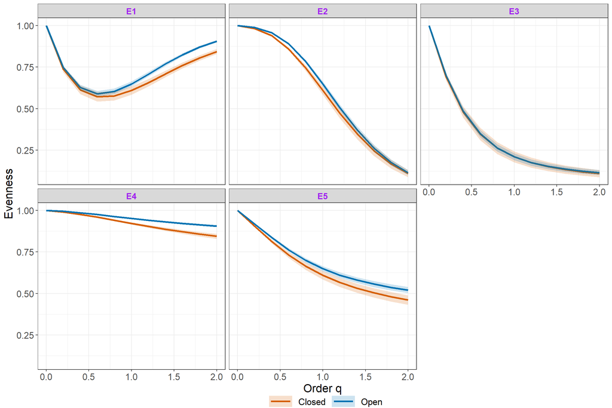

```r
ggEvenness(output1)
```

### Estimated evenness profiles for abundance data with default SC = Cmax

Use abundance data `Data_spider` to compute estimated evenness with default `SC = NULL` (Cmax = 0.994). Here only show the output for first class of evenness.

```r
data(Data_spider)
output2 <- Evenness(data = Data_spider, datatype = "abundance",
                    method = "Estimated", SC = NULL, E.class = 1:5)
output2$E1
   Order.q Evenness    s.e. Even.LCL Even.UCL Assemblage    Method    SC
1      0.0    1.000 0.00000    1.000    1.000       Open Estimated 0.994
2      0.2    0.728 0.01544    0.697    0.758       Open Estimated 0.994
3      0.4    0.601 0.01988    0.562    0.640       Open Estimated 0.994
4      0.6    0.563 0.01960    0.524    0.601       Open Estimated 0.994
5      0.8    0.580 0.01719    0.546    0.614       Open Estimated 0.994
6      1.0    0.630 0.01391    0.602    0.657       Open Estimated 0.994
7      1.2    0.694 0.01061    0.673    0.715       Open Estimated 0.994
8      1.4    0.760 0.00790    0.745    0.776       Open Estimated 0.994
9      1.6    0.819 0.00600    0.807    0.831       Open Estimated 0.994
10     1.8    0.867 0.00473    0.858    0.877       Open Estimated 0.994
11     2.0    0.904 0.00384    0.897    0.912       Open Estimated 0.994
12     0.0    1.000 0.00000    1.000    1.000     Closed Estimated 0.994
13     0.2    0.700 0.03484    0.631    0.768     Closed Estimated 0.994
14     0.4    0.567 0.04460    0.479    0.654     Closed Estimated 0.994
15     0.6    0.525 0.04400    0.439    0.612     Closed Estimated 0.994
16     0.8    0.537 0.03863    0.461    0.612     Closed Estimated 0.994
17     1.0    0.578 0.03115    0.516    0.639     Closed Estimated 0.994
18     1.2    0.633 0.02339    0.587    0.679     Closed Estimated 0.994
19     1.4    0.693 0.01671    0.660    0.725     Closed Estimated 0.994
20     1.6    0.749 0.01188    0.726    0.772     Closed Estimated 0.994
21     1.8    0.799 0.00896    0.781    0.816     Closed Estimated 0.994
22     2.0    0.840 0.00742    0.826    0.855     Closed Estimated 0.994
```

The following commands plot the evenness curves for five classes, along with its confidence interval for q between 0 to 2.

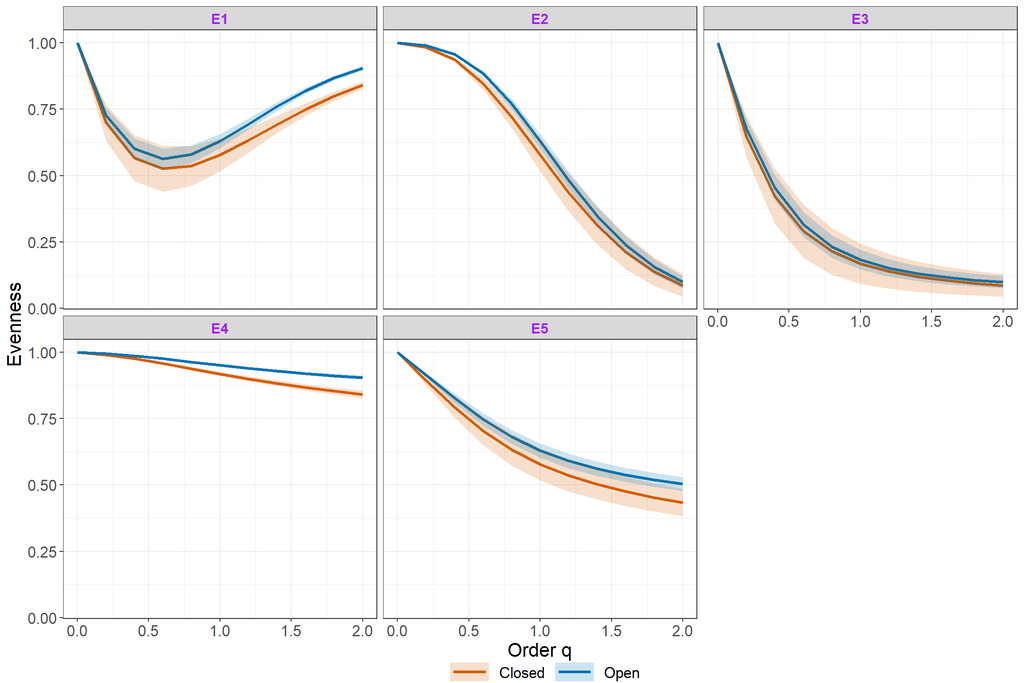

```r
ggEvenness(output2)
```

### Observed evenness profiles for incidence data

Use incidence frequency data `Woody plants` to compute observed evenness. Here only show the output for first class of evenness.

```r
data(Data_woody_plant)
output3 <- Evenness(data = Data_woody_plant[c(1,4)], datatype = "incidence_raw",
                    method = "Observed", E.class = 1:5)
output3$E1
   Order.q Evenness     s.e. Even.LCL Even.UCL  Assemblage   Method
1      0.0    1.000 0.000000    1.000    1.000 Upper_cloud Observed
2      0.2    0.855 0.003816    0.847    0.862 Upper_cloud Observed
3      0.4    0.789 0.005348    0.779    0.800 Upper_cloud Observed
4      0.6    0.779 0.005473    0.768    0.790 Upper_cloud Observed
5      0.8    0.806 0.004732    0.796    0.815 Upper_cloud Observed
6      1.0    0.851 0.003574    0.844    0.858 Upper_cloud Observed
7      1.2    0.898 0.002403    0.893    0.903 Upper_cloud Observed
8      1.4    0.937 0.001477    0.934    0.940 Upper_cloud Observed
9      1.6    0.964 0.000858    0.963    0.966 Upper_cloud Observed
10     1.8    0.981 0.000483    0.980    0.982 Upper_cloud Observed
11     2.0    0.990 0.000268    0.990    0.991 Upper_cloud Observed
12     0.0    1.000 0.000000    1.000    1.000     Monsoon Observed
13     0.2    0.845 0.002868    0.839    0.850     Monsoon Observed
14     0.4    0.781 0.003899    0.773    0.788     Monsoon Observed
15     0.6    0.776 0.003886    0.769    0.784     Monsoon Observed
16     0.8    0.810 0.003254    0.803    0.816     Monsoon Observed
17     1.0    0.859 0.002346    0.855    0.864     Monsoon Observed
18     1.2    0.909 0.001475    0.906    0.912     Monsoon Observed
19     1.4    0.947 0.000830    0.945    0.949     Monsoon Observed
20     1.6    0.972 0.000435    0.971    0.973     Monsoon Observed
21     1.8    0.986 0.000220    0.985    0.986     Monsoon Observed
22     2.0    0.993 0.000110    0.993    0.993     Monsoon Observed
```

The following commands plot the evenness curves for five classes, along with its confidence interval for q between 0 to 2.

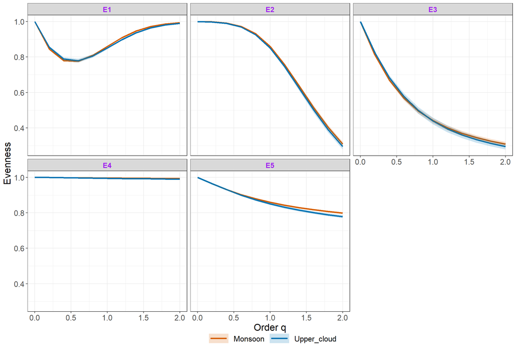

```r
ggEvenness(output3)
```

### Estimated evenness profiles for incidence data with default SC = Cmax

Use incidence frequency data `Woody plants` to compute estimated evenness with `SC = NULL` (Cmax = 0.993). Here only show the output for first class of evenness.

```r
data(Data_woody_plant)
output4 <- Evenness(data = Data_woody_plant[c(1,4)], datatype = "incidence_raw",
                    method = "Estimated", SC = NULL, E.class = 1:5)
output4$E1
   Order.q Evenness     s.e. Even.LCL Even.UCL  Assemblage    Method    SC
1      0.0    1.000 0.000000    1.000    1.000 Upper_cloud Estimated 0.993
2      0.2    0.830 0.010369    0.810    0.851 Upper_cloud Estimated 0.993
3      0.4    0.757 0.013864    0.729    0.784 Upper_cloud Estimated 0.993
4      0.6    0.747 0.013598    0.721    0.774 Upper_cloud Estimated 0.993
5      0.8    0.780 0.011245    0.758    0.802 Upper_cloud Estimated 0.993
6      1.0    0.832 0.008030    0.817    0.848 Upper_cloud Estimated 0.993
7      1.2    0.887 0.004989    0.877    0.897 Upper_cloud Estimated 0.993
8      1.4    0.931 0.002742    0.926    0.937 Upper_cloud Estimated 0.993
9      1.6    0.961 0.001374    0.959    0.964 Upper_cloud Estimated 0.993
10     1.8    0.980 0.000651    0.978    0.981 Upper_cloud Estimated 0.993
11     2.0    0.990 0.000307    0.989    0.990 Upper_cloud Estimated 0.993
12     0.0    1.000 0.000000    1.000    1.000     Monsoon Estimated 0.993
13     0.2    0.827 0.007892    0.812    0.842     Monsoon Estimated 0.993
14     0.4    0.758 0.010051    0.738    0.778     Monsoon Estimated 0.993
15     0.6    0.755 0.009405    0.737    0.774     Monsoon Estimated 0.993
16     0.8    0.793 0.007416    0.778    0.807     Monsoon Estimated 0.993
17     1.0    0.848 0.005030    0.838    0.858     Monsoon Estimated 0.993
18     1.2    0.902 0.002949    0.897    0.908     Monsoon Estimated 0.993
19     1.4    0.944 0.001522    0.941    0.947     Monsoon Estimated 0.993
20     1.6    0.970 0.000717    0.969    0.972     Monsoon Estimated 0.993
21     1.8    0.985 0.000322    0.985    0.986     Monsoon Estimated 0.993
22     2.0    0.993 0.000146    0.993    0.993     Monsoon Estimated 0.993
```

The following commands plot the evenness curves for five classes, along with its confidence interval for q between 0 to 2.

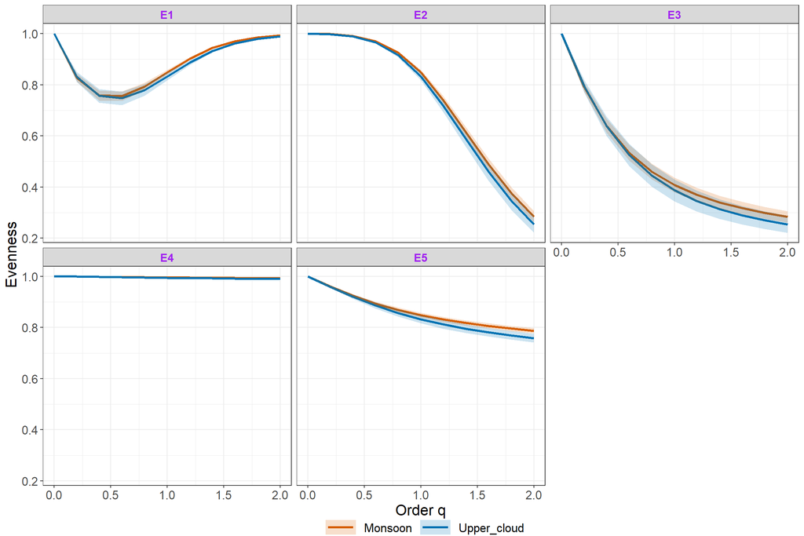

```r
ggEvenness(output4)
```

## License

The iNEXT.4steps package is licensed under the GPLv3. To help refine `iNEXT.4steps`, your comments or feedback would be welcome (please send them to Anne Chao or report an issue on the iNEXT.4steps github [iNEXT.4steps_github](https://github.com/AnneChao/iNEXT.4steps).